# Investigating the effects of excess body weight on presentation, outcomes and gene signatures in multiple myeloma

BMIN 5030 Final Project

Beatrice Razzo

# 1 OVERVIEW:

This study aims to identify any clinical, cytogenetic and outcome associations between newly diagnosed multiple myeloma (NDMM) and excess body weight (EBW) in participants of the MMRF CoMMpass study. Data include clinical information at diagnosis including ISS stage, BMI and ECOG performance status and, cytogenetics including whole genome, whole exome and bulk RNA sequencing. Outcome data is available over a 6 year follow-up period. We will use body mass index (BMI) as a surrogate marker for excess body weight though it is an imperfect measure of adiposity. Please find my Github Repository for the final project [here](https://github.com/bearazzo/BMIN503_Final_Project).

# 2 INTRODUCTION:

Multiple myeloma (MM) is the second most common blood cancer diagnosis, with over 20,000 cases diagnosed each year in the United States. Age, race and genetic factors are known predisposing risk factors, but obesity is the only modifiable characteristic consistently implicated in the development of both MGUS and MM (Carson, Bates, and Tomasson 2014; Landgren et al. 2010; Wallin and Larsson 2011). Persons with excess body weight are 10-20% more likely to develop multiple myeloma, with an estimated number of 12,480 cases attributed to excess body weight in the United States between 2011-2015 (Islami et al. 2019). In several recent meta-analyses, the risk of mortality was increased in multiple myeloma patients with excess body weight (RR 1.16-1.22) (Abar et al. 2019; Teras et al. 2014; Wallin and Larsson 2011). In contrast, other analyses have failed to suggest this association (Beason et al. 2013; Vogl et al. 2011). Overall, the true impact of obesity on development and outcomes in MM is unknown, with most published data reflecting diagnosis and treatment between 1995-2010. 5-year mean overall survival of MM has changed from 34.5 to 49.6% during this period due to the advent of new therapeutic modalities (Fonseca et al. 2017). Therefore, further studies are warranted to reflect the clinical impact of excess body weight under today’s disease stratification and treatment strategies.

The myeloma-obesity association is of interest not only due to potential measures that address population-level disparities and cancer prevention, but also because of insights it may provide into the myeloma pre-cancerous state and process of malignant transformation. The pathophysiological basis of this association is not fully understood, with systemic inflammation and secondary immune dysfunction as putative driver mechanisms. Inflammation induces chronic cellular stressors that may adversely affect prognosis in patient with MM. Patients with obesity (based on BMI or increased waist to hip ratio) were reported to have increasing rates of clonal hematopoiesis of intederminate potential (CHIP)(Kumar ASH 2021 abstract). CHIP has been associated with adverse outcomes in multiple myeloma patients undergoing transplant (Mouhieddine Nature communications 2020). BMI is also negatively associated with telomere length (Gielen American Journal of Clinical Nutrition 2018). Short telomere length has been associated with adverse outcomes in a number of cancers including chronic lymphocytic leukemia and MM where it associated with high risk GEP defined group (Wu Blood 2003, Steinbrecher Leuk Lymph 2018). Lastly, the APOBEC3 (apolipoprotein B mRNA editing enzyme catalytic polypeptide 3) family of cytidine deaminases is responsible for two mutational signatures (SBS2 and SBS13) found in cancer genomes. APOBEC3 enzymes are activated in response to viral infection and causes DNA damage and promotes genomic instability in multiple myeloma.

As such, this report will include data analysis of known clinical and cytogenetic prognostic features in MM and also exploration of genetic features that may be mechanistically associated with MM as an obesity related cancer (ORC). I thank my mentors Dr. Eileen Boyle and Dr. Faith Davies at NYU Langone for their ongoing support in completing this project.

# 3 METHODS/ RESULTS:

## 3.1 Data Source

The MMRF CoMMpass database (MMRF in short hereafter) is a study designed to prospectively profile newly diagnosed, treatment naive MM (NDMM) from more than 1000 patients with longitudinal clinical follow up. Tumor specimens collected at diagnosis and relapse are interrogated by whole-exome, modified low pass whole-genome, and or RNA sequencing. The longitudinal component required clinical follow-up of each patient with collection of clinical parameters four times annually over a period of 10 years. Furthermore, each patient participating in the study underwent an IMID and/or Proteasome inhibitor-based treatment regimen at diagnosis determined by the treating hematologist.

Of all samples available, 980 underwent germline WGS - all were analyzed for clonal hematopoiesis and 911 were analyzed for leukocyte telomere length. There were 848 matching tumor specimens available - 809 underwent tumor WGS (747 analyzed for complex rearrangements and 807 analyzed for tumor telemere length), 848 underwent tumor WES (included analyses for mutations, translocations and CNA) and 683 underwent bulk RNA sequencing. Most patients for which BMI information is available also contributed samples for genetic information as described above. Full WES, WGS and RNA seq processing methods has been previously published in (Boyle Leukemia 2021). Individual methods sections will introduce some additional data processing not done by me (provided by Dr. Boyle) but specific to data used in this project.

## 3.2 Data loading

All libraries loaded as follows. The .csv files containing data extracted between 2018-2020 by Dr. Eileen Boyle at NYU Langone were loaded and modified according to the following code. They are all available as .csv on github. Data from 758 of 1273 participants contained height and weight at the time of diagnosis and this subset of patients is primarily used in the following analyses given the focus of this report. Demographic distribution does not significantly differ from the overall cohort (data not shown, previously published in (Boyle Leukemia 2021).

```r
library(survival)
library(ranger)
library(ggplot2)
library(dplyr)
library(ggfortify)
library(tibble)
library(readr)
library(survminer)
library(RColorBrewer)
mycolors=brewer.pal(8,"Set2")
library(cowplot)
library(modelsummary)
library(viridis)
library(tidytidbits)
library(survivalAnalysis)
library(purrr)
library(stringr)

MMRFfull <- read.csv("~/Documents/BMIN 5030/Final Project/Raw Files/Razzo_MMRF raw csv.csv", header = T, fill = TRUE, row.name = NULL)
MMRFfull <- rename(MMRFfull, Patient_ID = Patient)

MMRFclean <- read.csv("~/Documents/BMIN 5030/Final Project/Raw Files/Razzo_MMRF clean csv.csv", header = T, fill = TRUE, row.name = NULL)
MMRFclean <- rename(MMRFclean, Sex = D_Gender, Race = D_Race, AgeDx = D_Age, BMIDx = BMI, ISSDx = D_ISS) %>%
  mutate(BMI_cat_4 = factor(BMI_cat_4, levels = c(0,1,2,3), labels = c("<18.5", "18.5-25", "25-30", ">30"))) %>%
  mutate(BMI_cat_6 = factor(BMI_cat_6, levels = c(0,1,2,3,4,5), labels = c("<18.5", "18.5-25", "25-30", "30-35", "35-40", ">40"))) %>%
  mutate(FU_status = factor(FU_status, levels = c(0,1), labels = c("Not censored", "Censored"))) %>%
  mutate(OS_status = factor(OS_status, levels = c(0,1), labels = c("Alive", "Dead"))) %>%
  mutate(ISSDx = factor(ISSDx, level = c(1,2,3)))

MMRFclean$Translocation_Summary <- as.factor(MMRFclean$Translocation_Summary)
MMRFclean$HRD <- as.factor(MMRFclean$HRD)
MMRFclean$Sex <- as.factor(MMRFclean$Sex)
MMRFclean$RNA_high_risk <- as.factor(MMRFclean$RNA_high_risk)
MMRFclean$OS_status_num <- as.numeric(MMRFclean$OS_status)

#Merging full and clean datasets
MMRFadd <- read.csv("~/Documents/BMIN 5030/Final Project/BMIN503_Final_Project/MMRF clinical add on.csv", header = T, fill = TRUE, row.name = NULL)
MMRFadd <- rename(MMRFadd, Patient_ID = Patient)
MMRFcleanadd <- right_join(MMRFclean, MMRFadd, by = "Patient_ID")
MMRFcleanadd <- rename(MMRFcleanadd, HxTransplant = TRT_1_bmtx_n)
MMRFcleanadd <- MMRFcleanadd %>% mutate(HxTransplant = factor(HxTransplant, levels = c(0,1), labels = c("No", "Yes")))
MMRFcleanadd$ECOG <- as.factor(MMRFcleanadd$ECOG)

#Selecting participants with BMI data for further analyses
MMRFcleanbmionly <- MMRFcleanadd %>%
  filter(!is.na(BMIDx))
MMRFcleanbmionly$age_group <- cut(MMRFclean$AgeDx,
                       breaks=c(0, 54, 64, 74, 110),
                       labels=c("<55", "55-64", "65-74", ">74"))
MMRFfullcgsumm <- MMRFfull[1:1273, c("Patient_ID","TP53_Loss","CKS1B_Gain")]
MMRFcleanbmionly <- inner_join(MMRFcleanbmionly, MMRFfullcgsumm, by = "Patient_ID")
MMRFcleanbmionly$CKS1B_Gain_binary <- case_when(MMRFcleanbmionly$CKS1B_Gain == -2 ~ 'No',
                                          MMRFcleanbmionly$CKS1B_Gain == 1 ~ 'No',
                                          MMRFcleanbmionly$CKS1B_Gain == 2 ~ 'No',
                                          MMRFcleanbmionly$CKS1B_Gain == 3 ~ '1q gain',
                                          MMRFcleanbmionly$CKS1B_Gain == 4 ~ '1q gain')

MMRFcleanbmionly$TP53_Loss_binary <- case_when(MMRFcleanbmionly$TP53_Loss == -2 ~ '17p del',
                                          MMRFcleanbmionly$TP53_Loss == 1 ~ '17p del',
                                          MMRFcleanbmionly$TP53_Loss == 2 ~ 'No',
                                          MMRFcleanbmionly$TP53_Loss == 3 ~ 'No',
                                          MMRFcleanbmionly$TP53_Loss == 4 ~ 'No')
MMRFcleanbmionly$t414_binary <- case_when(MMRFcleanbmionly$Translocation_Summary == "t(4;14)" ~ 't(4;14)',
                                          TRUE ~ 'No')
MMRFcleanbmionly$t1416_binary <- case_when(MMRFcleanbmionly$Translocation_Summary == "t(14;16)" ~ 't(14;16)',
                                          TRUE ~ 'No')
MMRFcleanbmionly$EBW_binary <- case_when(MMRFcleanbmionly$BMIDx >= 30 ~ '>30',
                                         TRUE ~ '<30')

MMRFcleanbmionly$CKS1B_Gain_binary <- as.factor(MMRFcleanbmionly$CKS1B_Gain_binary)
MMRFcleanbmionly$CKS1B_Gain_binary <- factor(MMRFcleanbmionly$CKS1B_Gain_binary, levels = c("No", "1q gain"))
MMRFcleanbmionly$TP53_Loss_binary <- as.factor(MMRFcleanbmionly$TP53_Loss_binary)
MMRFcleanbmionly$TP53_Loss_binary <- factor(MMRFcleanbmionly$TP53_Loss_binary, levels = c("No", "17p del"))
MMRFcleanbmionly$t414_binary <- as.factor(MMRFcleanbmionly$t414_binary)
MMRFcleanbmionly$t1416_binary <- as.factor(MMRFcleanbmionly$t1416_binary)
MMRFcleanbmionly$EBW_binary <- as.factor(MMRFcleanbmionly$EBW_binary)
MMRFcleanbmionly$OS_status_num <- as.numeric(MMRFcleanbmionly$OS_status)

#Adding in apobec data
MMRFapobec <-read.csv("~/Documents/BMIN 5030/Final Project/BMIN503_Final_Project/MMRF apobec values.csv", header = T, fill = TRUE, row.name = NULL)
MMRFapobec <- rename(MMRFapobec, Patient_ID = X)

#Adding in CHIP data
MMRFfullchip <- MMRFfull[1:1273, c("Patient_ID","DNMT3A_Loss","NS_TET2")]
MMRFfullchip$DNMT3A_Loss_binary <- case_when(MMRFfullchip$DNMT3A_Loss == -2 ~ 'DNMT3A loss',
                                          MMRFfullchip$DNMT3A_Loss == 1 ~ 'DNMT3A loss',
                                          MMRFfullchip$DNMT3A_Loss == 2 ~ 'No',
                                          MMRFfullchip$DNMT3A_Loss == 3 ~ 'No',
                                          MMRFfullchip$DNMT3A_Loss == 4 ~ 'No')
MMRFfullchip$DNMT3A_Loss_binary <- as.factor(MMRFfullchip$DNMT3A_Loss_binary)
MMRFcleanbmionly <- inner_join(MMRFcleanbmionly, MMRFfullchip, by = "Patient_ID")

#Adding in differential gene expression results
MMRFdge <-read.csv("~/Documents/BMIN 5030/Final Project/BMIN503_Final_Project/DGE by BMI group.csv", header = T, fill = TRUE, row.name = NULL)
```

## 3.3 Conventional clinical and genetic features and their relationship with BMI distribution

### 3.3.1 Demographic and clinical data according to BMI

The histogram below depicts the BMI distribution at the time of diagnosis of MMRF database participants. The numeric and percent breakdown of some of the clinical and cytogenetic information has been included in the following summary table for reference.

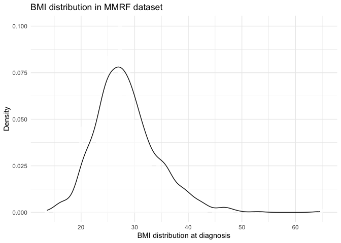

```r
ggplot(data = MMRFclean, aes(x = BMIDx)) +
  geom_histogram(aes(y= ..density..), fill = "white", alpha = 0.7, binwidth = 0.8)+
  geom_density() +
  labs(title="BMI distribution in MMRF dataset", x ="BMI distribution at diagnosis", y = "Density") +
  theme_minimal ()
```

```r
#Baseline Patient Characteristics, BMI 4 categories
patientcharacteristics <- MMRFclean %>% gtsummary::tbl_summary()
MMRFclean %>%
  dplyr::select(c(Sex, Race, AgeDx, BMI_cat_4, ISSDx, IMWG_Risk, Translocation_Summary)) %>%
  gtsummary::tbl_summary(by = BMI_cat_4) %>%
  gtsummary::add_p()
```

| **Characteristic** | **<18.5**, N = 18<sup>1</sup> | **18.5-25**, N = 197<sup>1</sup> | **25-30**, N = 294<sup>1</sup> | **>30**, N = 249<sup>1</sup> | **p-value**<sup>2</sup> |
| --- | --- | --- | --- | --- | --- |
| Sex |  |  |  |  | <0.001 |
| Female | 14 (78%) | 91 (49%) | 87 (31%) | 97 (39%) |  |
| Male | 4 (22%) | 95 (51%) | 198 (69%) | 150 (61%) |  |
| Unknown | 0 | 11 | 9 | 2 |  |
| Race |  |  |  |  |  |
| ASIAN | 1 (5.6%) | 6 (3.0%) | 4 (1.4%) | 2 (0.8%) |  |
| BLACKORAFRICAN | 7 (39%) | 33 (17%) | 35 (12%) | 48 (19%) |  |
| OTHER | 2 (11%) | 8 (4.1%) | 16 (5.4%) | 13 (5.2%) |  |
| WHITE | 8 (44%) | 150 (76%) | 239 (81%) | 186 (75%) |  |
| AgeDx | 64 (60, 70) | 65 (57, 73) | 64 (58, 71) | 64 (55, 68) | 0.032 |
| ISSDx |  |  |  |  |  |
| 1 | 2 (11%) | 65 (35%) | 102 (36%) | 85 (35%) |  |
| 2 | 12 (67%) | 64 (34%) | 105 (37%) | 92 (38%) |  |
| 3 | 4 (22%) | 58 (31%) | 77 (27%) | 67 (27%) |  |
| Unknown | 0 | 10 | 10 | 5 |  |
| IMWG_Risk |  |  |  |  |  |
| High Risk | 2 (11%) | 27 (15%) | 36 (13%) | 29 (13%) |  |
| Low Risk | 1 (5.6%) | 13 (7.1%) | 24 (8.9%) | 31 (14%) |  |
| Standard Risk | 15 (83%) | 144 (78%) | 210 (78%) | 167 (74%) |  |
| Unknown | 0 | 13 | 24 | 22 |  |
| Translocation_Summary |  |  |  |  |  |
| None | 11 (61%) | 120 (61%) | 174 (59%) | 158 (63%) |  |
| t(11;14) | 3 (17%) | 34 (17%) | 67 (23%) | 42 (17%) |  |
| t(14;16) | 0 (0%) | 8 (4.1%) | 12 (4.1%) | 9 (3.6%) |  |
| t(14;20) | 1 (5.6%) | 2 (1.0%) | 2 (0.7%) | 6 (2.4%) |  |
| t(4;14) | 2 (11%) | 29 (15%) | 33 (11%) | 29 (12%) |  |
| t(6;14) | 0 (0%) | 0 (0%) | 5 (1.7%) | 4 (1.6%) |  |
| t(8;14) | 1 (5.6%) | 4 (2.0%) | 1 (0.3%) | 1 (0.4%) |  |

<sup>1</sup> n (%); Median (IQR)  
<sup>2</sup> Pearson's Chi-squared test; Kruskal-Wallis rank sum test

The scatter plot shows a small but statistically significant decline in BMI with older age at diagnosis. Later analyses will need to take this relationship into account, because age has been shown to have significant prognostic implications as previously published by our group (Boyle Leukemia 2021). Although there was a trend toward increased mean BMI in males, this was not a statistically significant trend. Similarly, there were no significant variations in BMI distribution according to race. Mean BMI was also not significantly different according to ISS stage at diagnosis. ECOG performance status was distributed evenly though patients with BMI >18.5. There was an increased proportion of ECOG >0 in underweight patients suggesting a sicker patient population. Transplant status did not significantly change according to BMI group.

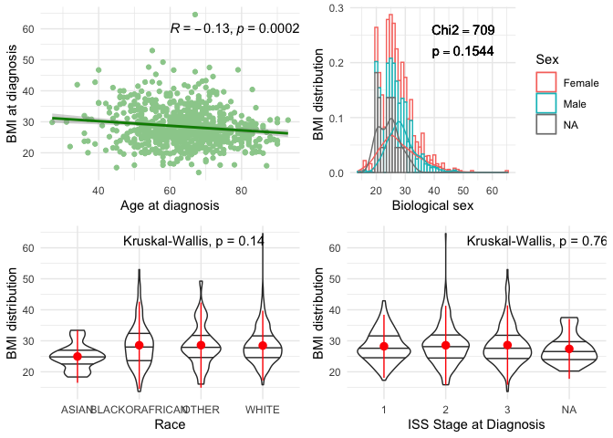

```r
ggplot1<- ggplot(MMRFclean, aes(x = AgeDx, y = BMIDx)) +
    geom_point(color = "darkseagreen3") +
    geom_smooth(method = "lm", color = "green4") +
    labs(x = "Age at diagnosis", y = "BMI at diagnosis") +
    stat_cor(method = "pearson", label.x = 60, label.y = 60) +
    theme_minimal ()

#KRUSKAL-WALLIS, BMI DISTRIBUTION BY SEX
KWsex<- kruskal.test(Sex~BMIDx, MMRFclean)
mylabel1 <- bquote(p == .(format(KWsex$p.value, digits = 5)))
mylabel2 <- bquote(Chi2 == .(format(KWsex$statistic, digits = 2)))

ggplot2 <- ggplot(data = MMRFclean, aes(x = BMIDx, color = Sex, na.rm = TRUE)) +
  geom_histogram(aes(y= ..density.., color=Sex), na.rm=TRUE, Male = "blue", Female = "red", fill = "white", alpha = 0.7, binwidth=1)+
  geom_density(Male = "blue", Female = "red", na.rm=TRUE) +
  theme_minimal() +
  labs(x = "Biological sex", y = "BMI distribution") +
  annotate("text", x=50, y=0.26, label=mylabel2) +
  annotate("text", x=50, y=0.22, label=mylabel1)

ggplot3 <- ggplot(data = MMRFclean, aes(x = factor(Race), y = BMIDx)) +
  geom_violin(draw_quantiles = c(0.25, 0.5, 0.75)) +
  stat_summary(fun.data=mean_sdl, mult=1,
                 geom="pointrange", color="red") +
  theme_minimal() +
  stat_compare_means (label.x = 2.2, label.y = 61) +
  labs(x = "Race", y = "BMI distribution")

ggplot4 <- ggplot(data = MMRFclean, aes(x = factor(ISSDx), y = BMIDx)) +
  geom_violin(draw_quantiles = c(0.25, 0.5, 0.75)) +
  stat_summary(fun.data=mean_sdl,
                 geom="pointrange", color="red") +
  theme_minimal() +
  stat_compare_means (label.x = 2.8, label.y = 61) +
  labs(x = "ISS Stage at Diagnosis", y = "BMI distribution")

#ECOG status distribution - proportion stacked barplot
BMIECOGdf <- MMRFcleanbmionly[1:758, c("BMI_cat_4","ECOG")]
BMIECOGdf <- BMIECOGdf %>% filter(!is.na(ECOG))

ggplot6 <- ggplot(BMIECOGdf, aes(fill=ECOG, y=1, x=BMI_cat_4)) +
  geom_bar(position="fill", stat="identity") +
  labs(x = "BMI WHO category", y = "Proportion of patients") +
  theme_minimal()

#Transplant distribution - proportion stacked barplot
BMItranspdf <- MMRFcleanbmionly[1:758, c("HxTransplant","BMI_cat_4")]
BMItranspdf <- BMItranspdf %>% filter(!is.na(HxTransplant))

ggplot7 <- ggplot(BMItranspdf, aes(fill=HxTransplant, y=1, x=BMI_cat_4)) +
  geom_bar(position="fill", stat="identity") +
  labs(x = "BMI WHO category", y = "Proportion of patients") +
  theme_minimal()

plot_grid(ggplot1, ggplot2, ggplot3, ggplot4, ncol = 2)
```

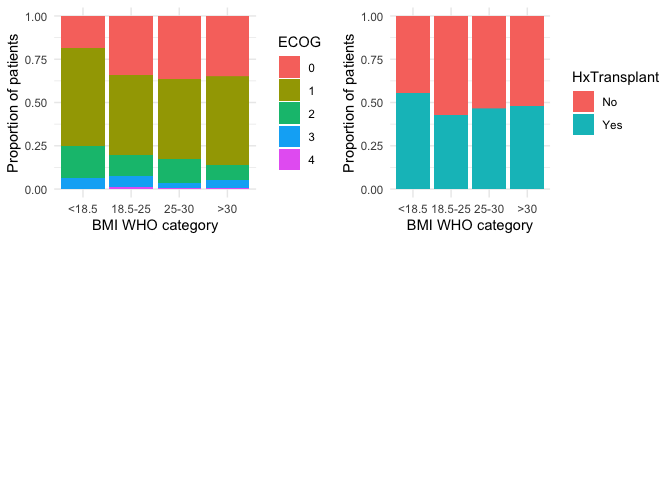

```r
plot_grid(ggplot6, ggplot7, ncol = 2, nrow =2)
```

### 3.3.2 Characterization of BMI at diagnosis with respect to MM related cytogenetic changes and RNA risk category

In regards to the BMI distribution of the most common MM related translocations, most did not segregate with BMI. Although t(8;14) did appear to have statistically significant distribution with respect to weight, it is a rare translocation often associated with later clonal evolution so unlikely to be a clinically significant finding in regards to newly diagnosed genetic drivers. 1q gain and 17p deletion are included in newer MM staging systems (R-ISS and R2-ISS) and were obtained in this subset by tumor NGS. Neither appear to change in frequency according to BMI.

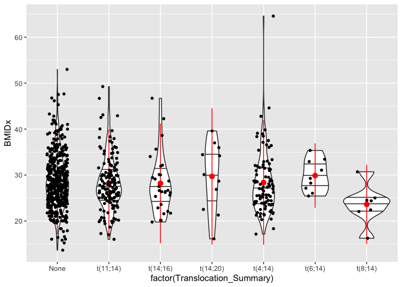

```r
#Translocation Summary
ggplot(data = MMRFclean, aes(x = factor(Translocation_Summary), y = BMIDx)) +
    geom_violin(draw_quantiles = c(0.25, 0.5, 0.75)) +
    stat_summary(fun.data=mean_sdl, mult=1,
                 geom="pointrange", color="red") +
    geom_jitter(shape=16, position=position_jitter(0.2))
```

```r
lm4<- lm(BMIDx ~ Translocation_Summary, data = MMRFclean)
modelsummary(list(lm4), coef_omit = "Intercept",
             statistic = c("p = {p.value}"),
             estimate = "{estimate} [{conf.low}, {conf.high}]")
```

|  | Model 1 |
| --- | --- |
| Translocation_Summaryt(11;14) | −0.318 [−1.422, 0.787] |
|  | p = 0.573 |
| Translocation_Summaryt(14;16) | −0.342 [−2.569, 1.885] |
|  | p = 0.763 |
| Translocation_Summaryt(14;20) | 1.169 [−2.380, 4.719] |
|  | p = 0.518 |
| Translocation_Summaryt(4;14) | −0.168 [−1.490, 1.154] |
|  | p = 0.803 |
| Translocation_Summaryt(6;14) | 1.342 [−2.573, 5.258] |
|  | p = 0.501 |
| Translocation_Summaryt(8;14) | −4.917 [−9.347, −0.487] |
|  | p = 0.030 |
| Num.Obs. | 758 |
| R2 | 0.008 |
| R2 Adj. | 0.00007 |
| AIC | 4857.6 |
| BIC | 4894.7 |
| Log.Lik. | −2420.824 |
| RMSE | 5.90 |

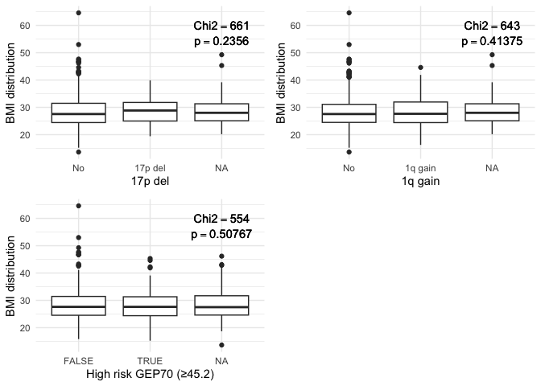

```r
#1q gain
KWhighrisk17pdel <- kruskal.test(TP53_Loss_binary~BMIDx, MMRFcleanbmionly)
mylabel7 <- bquote(p == .(format(KWhighrisk17pdel$p.value, digits = 5)))
mylabel8 <- bquote(Chi2 == .(format(KWhighrisk17pdel$statistic, digits = 2)))

ggplot9 <- ggplot(data = MMRFcleanbmionly, aes(x = factor(TP53_Loss_binary), y = BMIDx), na.rm = TRUE) +
  geom_boxplot() +
  theme_minimal() +
  labs(x = "17p del", y = "BMI distribution") +
  annotate("text", x=3, y=60, label=mylabel8) +
  annotate("text", x=3, y=54, label=mylabel7)

#17p del
KWhighrisk1q <- kruskal.test(CKS1B_Gain_binary~BMIDx, MMRFcleanbmionly)
mylabel5 <- bquote(p == .(format(KWhighrisk1q$p.value, digits = 5)))
mylabel6 <- bquote(Chi2 == .(format(KWhighrisk1q$statistic, digits = 2)))

ggplot8 <- ggplot(data = MMRFcleanbmionly, aes(x = factor(CKS1B_Gain_binary), y = BMIDx), na.rm = TRUE) +
  geom_boxplot() +
  theme_minimal() +
  labs(x = "1q gain", y = "BMI distribution") +
  annotate("text", x=3, y=60, label=mylabel6) +
  annotate("text", x=3, y=54, label=mylabel5)

#High risk GEP70 does not occur more frequently in patients with excess body weight
KWhighriskRNA <- kruskal.test(RNA_high_risk~BMIDx, MMRFclean)
mylabel3 <- bquote(p == .(format(KWhighriskRNA$p.value, digits = 5)))
mylabel4 <- bquote(Chi2 == .(format(KWhighriskRNA$statistic, digits = 2)))

ggplot5 <- ggplot(data = MMRFclean, aes(x = factor(RNA_high_risk), y = BMIDx), na.rm = TRUE) +
  geom_boxplot() +
  theme_minimal() +
  labs(x = "High risk GEP70 (≥45.2)", y = "BMI distribution") +
  annotate("text", x=3, y=60, label=mylabel4) +
  annotate("text", x=3, y=54, label=mylabel3)

plot_grid(ggplot9, ggplot8, ggplot5, ncol = 2)
```

### 3.3.3 Outcome Summary Statistics

There were no survival differences in outcomes with BMI stratified into the 4 WHO defined discrete categories or as a binary variable. Univariate cox proportional hazard regression also did not show an association with BMI as a continuous variable. Given the confounding effects of age and possibly sex on BMI, I also performed a multivariate cox regression to assess a BMI-survival association and again this was not demonstrated.

*Data validation with clinically established prognostic features*

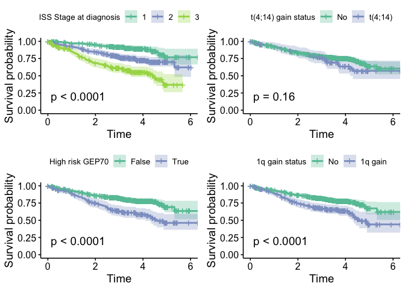

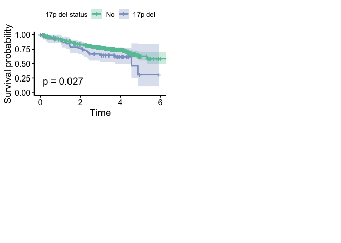

```r
splots1 <- list()

#ISS
km_fit_BMIISS <- survfit(Surv(OS_time, OS_status_num) ~ ISSDx, data=MMRFcleanbmionly)
splots1[[1]] <- ggsurvplot(km_fit_BMIISS,
           conf.int=TRUE,
           pval=TRUE,
           risk.table=FALSE,
           legend.labs=c("1", "2", "3"),
           legend.title="ISS Stage at diagnosis",
           palette=c("#66C2A5", "#8DA0CB","#A6D854", "#E5C494"),
           risk.table.height=0.1)

#High GEP70
km_fit_BMIRNA <- survfit(Surv(OS_time, OS_status_num) ~ RNA_high_risk, data=MMRFclean)
splots1[[2]] <- ggsurvplot(km_fit_BMIRNA,
           conf.int=TRUE,
           pval=TRUE,
           risk.table=FALSE,
           legend.labs=c("False", "True"),
           legend.title="High risk GEP70",
           palette=c("#66C2A5", "#8DA0CB","#A6D854", "#E5C494"),
           risk.table.height=0.1)

#t(4;14)
km_fit_BMI414 <- survfit(Surv(OS_time, OS_status_num) ~ t414_binary, data=MMRFcleanbmionly)
splots1[[3]] <- ggsurvplot(km_fit_BMI414,
           conf.int=TRUE,
           pval=TRUE,
           risk.table=FALSE,
           legend.labs=c("No", "t(4;14)"),
           legend.title="t(4;14) gain status",
           palette=c("#66C2A5", "#8DA0CB"),
           risk.table.height=0.1)

#1q gain
km_fit_BMI1q <- survfit(Surv(OS_time, OS_status_num) ~ CKS1B_Gain_binary, data=MMRFcleanbmionly)
splots1[[4]] <- ggsurvplot(km_fit_BMI1q,
           conf.int=TRUE,
           pval=TRUE,
           risk.table=FALSE,
           legend.labs=c("No","1q gain"),
           legend.title="1q gain status",
           palette=c("#66C2A5", "#8DA0CB"),
           risk.table.height=0.1)

#17p
km_fit_BMI17p <- survfit(Surv(OS_time, OS_status_num) ~ TP53_Loss_binary, data=MMRFcleanbmionly)
splots1[[5]] <- ggsurvplot(km_fit_BMI17p,
           conf.int=TRUE,
           pval=TRUE,
           risk.table=FALSE,
           legend.labs=c("No","17p del"),
           legend.title="17p del status",
           palette=c("#66C2A5", "#8DA0CB"),
           risk.table.height=0.1)

arrange_ggsurvplots(splots1, print = TRUE,
  ncol = 2, nrow = 2)
```

*Clinical factors and respective survival curves in this population subset*

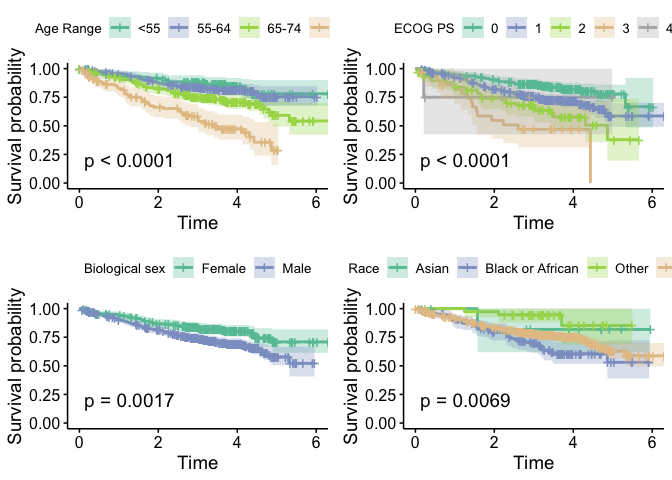

```r
splots3 <- list()

#Survival by Age Ranges - will use same as Age paper - PENDING
km_fit_BMIage <- survfit(Surv(OS_time, OS_status_num) ~ age_group, data=MMRFcleanbmionly)
splots3[[1]] <- ggsurvplot(km_fit_BMIage,
           conf.int=TRUE,
           pval=TRUE,
           risk.table=FALSE,
           legend.labs=c("<55", "55-64", "65-74", ">74"),
           legend.title="Age Range",
           palette=c("#66C2A5", "#8DA0CB","#A6D854", "#E5C494"),
           risk.table.height=0.1)

#Survival by Sex -
km_fit_BMIsex <- survfit(Surv(OS_time, OS_status_num) ~ Sex, data=MMRFclean)
splots3[[2]] <- ggsurvplot(km_fit_BMIsex,
           conf.int=TRUE,
           pval=TRUE,
           risk.table=FALSE,
           legend.labs=c("Female", "Male"),
           legend.title="Biological sex",
           palette=c("#66C2A5", "#8DA0CB","#A6D854", "#E5C494"),
           risk.table.height=0.1)

#Survival by ECOG PS
km_fit_BMIECOG <- survfit(Surv(OS_time, OS_status_num) ~ ECOG, data=MMRFcleanbmionly)
splots3[[3]] <- ggsurvplot(km_fit_BMIECOG,
           conf.int=TRUE,
           pval=TRUE,
           risk.table=FALSE,
           legend.labs=c("0", "1", "2", "3","4"),
           legend.title="ECOG PS",
           palette=c("#66C2A5", "#8DA0CB","#A6D854", "#E5C494", "#B3B3B3"),
           risk.table.height=0.1)

MMRFcleanbmionly$Race <- as.factor(MMRFcleanbmionly$Race)
km_fit_BMIrace <- survfit(Surv(OS_time, OS_status_num) ~ Race, data=MMRFclean)
splots3[[4]] <- ggsurvplot(km_fit_BMIrace,
           conf.int=TRUE,
           pval=TRUE,
           risk.table=FALSE,
           legend.labs=c("Asian", "Black or African", "Other", "White"),
           legend.title="Race",
           palette=c("#66C2A5", "#8DA0CB","#A6D854", "#E5C494"),
           risk.table.height=0.1)

splots2 <- list()

#Survival by BMI 4 discrete categories
km_fit_BMIcensor <- survfit(Surv(OS_time, OS_status_num) ~ BMI_cat_4, data=MMRFclean)
splots2[[1]] <- ggsurvplot(km_fit_BMIcensor,
           conf.int=FALSE,
           pval=TRUE,
           risk.table=FALSE,
           legend.labs=c("<18.5", "18.5-25","25-30",">30"),
           legend.title="BMI WHO category",
           palette=c("#66C2A5", "#8DA0CB","#A6D854", "#E5C494"),
           risk.table.height=0.1)

#Survival + or no EBW
km_fit_BMIEBW_binary <- survfit(Surv(OS_time, OS_status_num) ~ EBW_binary, data=MMRFcleanbmionly)
splots2[[2]] <- ggsurvplot(km_fit_BMIEBW_binary,
           conf.int=TRUE,
           pval=TRUE,
           risk.table=FALSE,
           legend.labs=c("<30", ">30"),
           legend.title="Presence of EBW",
           palette=c("#66C2A5", "#8DA0CB"),
           risk.table.height=0.1)

arrange_ggsurvplots(splots3, print = TRUE,
  ncol = 2, nrow = 2)
```

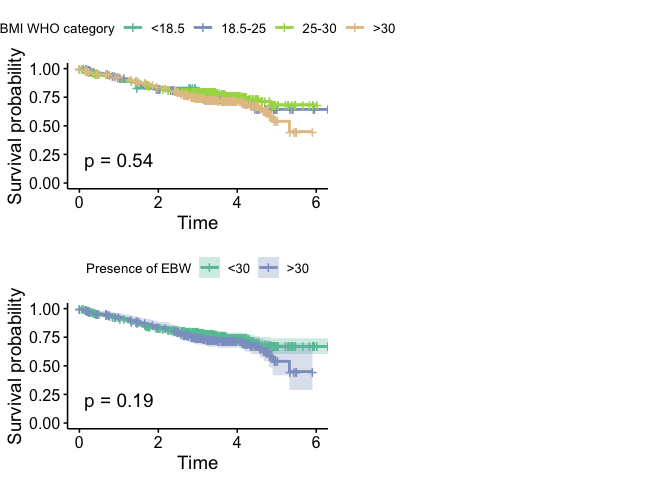

```r
arrange_ggsurvplots(splots2, print = TRUE,
  ncol = 2, nrow = 2)
```

```r
# UNIVARIATE with BMI as continuous and binary to confirm lack of association suggested with survplot of BMI as 4 discrete categories
unisurv1 <- coxph(Surv(OS_time, OS_status_num) ~ BMIDx, data = MMRFcleanbmionly)
summary(unisurv1)
```

```
## Call:
## coxph(formula = Surv(OS_time, OS_status_num) ~ BMIDx, data = MMRFcleanbmionly)
##
##   n= 758, number of events= 185
##
##          coef exp(coef) se(coef)    z Pr(>|z|)
## BMIDx 0.01153   1.01159  0.01213 0.95    0.342
##
##       exp(coef) exp(-coef) lower .95 upper .95
## BMIDx     1.012     0.9885    0.9878     1.036
##
## Concordance= 0.51  (se = 0.022 )
## Likelihood ratio test= 0.88  on 1 df,   p=0.3
## Wald test            = 0.9  on 1 df,   p=0.3
## Score (logrank) test = 0.9  on 1 df,   p=0.3
```

```r
unisurv2 <- coxph(Surv(OS_time, OS_status_num) ~ EBW_binary, data = MMRFcleanbmionly)
summary(unisurv2)
```

```
## Call:
## coxph(formula = Surv(OS_time, OS_status_num) ~ EBW_binary, data = MMRFcleanbmionly)
##
##   n= 758, number of events= 185
##
##                 coef exp(coef) se(coef)    z Pr(>|z|)
## EBW_binary>30 0.1981    1.2191   0.1513 1.31     0.19
##
##               exp(coef) exp(-coef) lower .95 upper .95
## EBW_binary>30     1.219     0.8203    0.9063      1.64
##
## Concordance= 0.514  (se = 0.018 )
## Likelihood ratio test= 1.69  on 1 df,   p=0.2
## Wald test            = 1.72  on 1 df,   p=0.2
## Score (logrank) test = 1.72  on 1 df,   p=0.2
```

```r
survmulti4 <- analyse_multivariate(MMRFcleanbmionly, vars(OS_time, OS_status_num), covariates = vars(BMIDx, AgeDx, Sex))
print(survmulti4$summaryAsFrame)
```

```
##   factor.id factor.name factor.value       HR  Lower_CI Upper_CI    Inv_HR
## 1     BMIDx       BMIDx <continuous> 1.024576 0.9993055 1.050486 0.9760132
## 2     AgeDx       AgeDx <continuous> 1.051692 1.0362255 1.067390 0.9508485
## 3  Sex:Male         Sex         Male 1.633946 1.1878161 2.247638 0.6120152
##   Inv_Lower_CI Inv_Upper_CI            p
## 1    0.9519401    1.0006950 5.672295e-02
## 2    0.9368648    0.9650409 2.603021e-11
## 3    0.4449116    0.8418811 2.545707e-03
```

Yet although no significant overall survival differences were dependent on BMI, I also wondered whether the established prognostic features are weighed differently in the obese and non-obese populations.

As such I performed multivariate cox regressions in patients with BMI <30 and BMI >30 as shown on in the following forest plots. In the 509 patients with BMI <30, most variables had at least a tendency toward HR >1. There was a small increment in HR/year of age gained and ISS was highly prognostic in this patient population. BMI again did not show any tendencies with respect to survival. In terms of patients with BMI >30, BMI also did not contribute toward mortality and age again demonstrated a small association. GEP70 high risk RNA expression profiling and ISS risk had lower HR compared to the non-obese group. The contribution of high-risk cytogenetic features was similar. No model validation was done due to small group sizes.

*Cox Regression models in patients with and without excess body weight using established prognostic features*

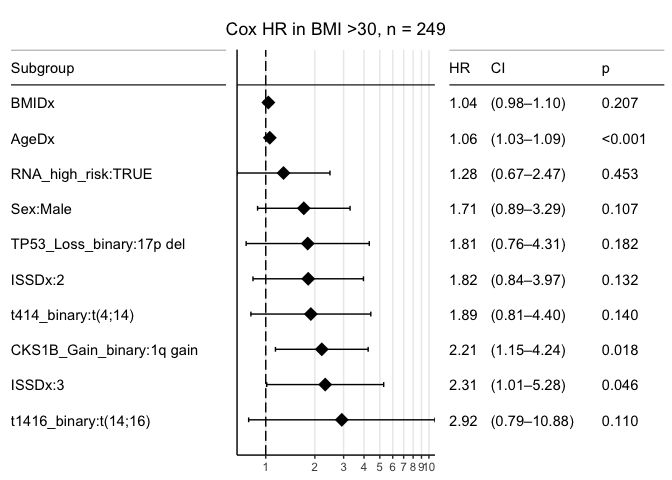

```r
#MULTIVARIATE OBESE (clinical and clinically established prognostic features), n = 249
MMRFcleanbmionlyEBW <- MMRFcleanbmionly %>%
  filter(BMIDx >= 30)
survmultiobese <- analyse_multivariate(MMRFcleanbmionlyEBW, vars(OS_time, OS_status_num), covariates = vars(BMIDx, AgeDx, Sex, ISSDx, RNA_high_risk, t414_binary, t1416_binary, CKS1B_Gain_binary, TP53_Loss_binary))
forest_plot(
  survmultiobese,
  use_one_hot = FALSE,
  factor_labeller = identity,
  endpoint_labeller = identity,
  orderer = ~order(HR),
  categorizer = NULL,
  relative_widths = c(1, 1, 1),
  ggtheme = theme_bw(),
  labels_displayed = c("factor"),
  label_headers = c(endpoint = "Endpoint", factor = "Subgroup", n = "n"),
  values_displayed = c("HR", "CI", "p"),
  value_headers = c(HR = "HR", CI = "CI", p = "p", n = "n", subgroup_n = "n"),
  HRsprintfFormat = "%.2f",
  psprintfFormat = "%.3f",
  p_lessthan_cutoff = 0.001,
  log_scale = TRUE,
  HR_x_breaks = seq(0, 10),
  HR_x_limits = NULL,
  factor_id_sep = ":",
  na_rm = TRUE,
  title = "Cox HR in BMI >30, n = 249",
  title_relative_height = 0.1,
  title_label_args = list(),
  base_papersize = dinA(4)
)
```

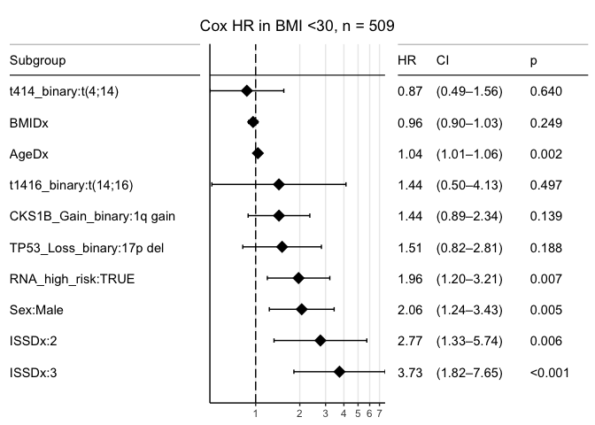

```r
#MULTIVARIATE NON-OBESE (clinical and clinically established prognostic features), n = 509
MMRFcleanbmionlynoEBW <- MMRFcleanbmionly %>%
  filter(BMIDx < 30)
survmultinonobese<- analyse_multivariate(MMRFcleanbmionlynoEBW, vars(OS_time, OS_status_num), covariates = vars(BMIDx, AgeDx, Sex, ISSDx, RNA_high_risk, t414_binary, t1416_binary, CKS1B_Gain_binary, TP53_Loss_binary))
forest_plot(
  survmultinonobese,
  use_one_hot = FALSE,
  factor_labeller = identity,
  endpoint_labeller = identity,
  orderer = ~order(HR),
  categorizer = NULL,
  relative_widths = c(1, 1, 1),
  ggtheme = theme_bw(),
  labels_displayed = c("factor"),
  label_headers = c(endpoint = "Endpoint", factor = "Subgroup", n = "n"),
  values_displayed = c("HR", "CI", "p"),
  value_headers = c(HR = "HR", CI = "CI", p = "p", n = "n", subgroup_n = "n"),
  HRsprintfFormat = "%.2f",
  psprintfFormat = "%.3f",
  p_lessthan_cutoff = 0.001,
  log_scale = TRUE,
  HR_x_breaks = seq(0, 10),
  HR_x_limits = NULL,
  factor_id_sep = ":",
  na_rm = TRUE,
  title = "Cox HR in BMI <30, n = 509",
  title_relative_height = 0.1,
  title_label_args = list(),
  base_papersize = dinA(4)
)
```

## 3.4 Exploratory genetic features and relationship with BMI distribution in this population

This section serves to explore whether there are any additional genetic features in patients with NDMM that may be associated with BMI at the time of diagnosis. The following are pathways are significantly implicated in inflammatory drivers and are putative mechanisms of obesity related cancers as introduced before.

### 3.4.1 NMF for Apobec signatures

*Methods (provided to and not performed by me):* Mutational signatures were called using non-negative matrix factorization (NMF) with counts per sample calculated for the six possible SNV types and the 16 possible 3-base sequence contexts, creating a table with 96 columns. The R package “NMF” was used for all calculations (CRAN - Package NMF). The number of signatures was determined by running 50 iterations of the algorithm for 2-7 signatures. A number of signatures was chosen that maximized the cophenetic distance and dispersion values. One thousand (1,000) iterations of the algorithm were run for that number of signatures. Cosine similarity was used to determine the Sanger signatures that were closest to the detected signatures.

*Results:* The % contribution of APOBEC signature mutations toward the composite mutation profile was estimated according to the NMF model above. APOBEC was reported as a proportion score (continuous variable) but also as a binary APOBEC enhanced and nonenhanced (>60% APOBEC). These summary stats were tested for correlation with BMI and did not reveal any significant relationships.

High contribution of APOBEC mutation signatures are known to cluster in high risk multiple myeloma translocations. I redemontrated this (statistically significant in the cases of t(14;16) and t(14;20)) in these data as a means of validation.

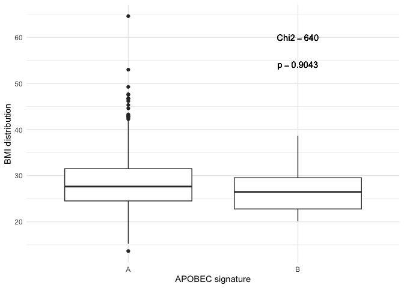

```r
#MMRFapobec (B) signatures with respect to BMI distribution
KWNMF2 <- kruskal.test(NMF2~BMIDx, MMRFcleanbmionly)
KWNMF2lab1 <- bquote(Chi2 == .(format(KWNMF2$statistic, digits = 2)))
KWNMF2lab2 <- bquote(p == .(format(KWNMF2$p.value, digits = 5)))

ggplot(data = MMRFcleanbmionly, aes(x = factor(NMF2), y = BMIDx), na.rm = TRUE) +
  geom_boxplot() +
  theme_minimal() +
  labs(x = "APOBEC signature", y = "BMI distribution") +
  annotate("text", x=2, y=60, label=KWNMF2lab1) +
  annotate("text", x=2, y=54, label=KWNMF2lab2)
```

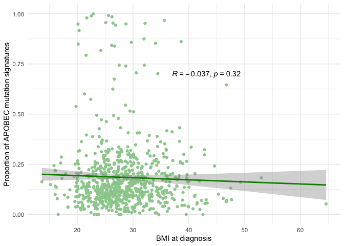

```r
#Cleaning duplicate apobec reads, adding df to MMRFcleanbmionly
MMRFapobec[c('ID1','ID2','samplenum','samplesource')] <- str_split_fixed(MMRFapobec$Patient_ID, "_", n=4)
MMRFapobec <- rename(MMRFapobec, Patient_ID_long = Patient_ID)
MMRFapobec$Patient_ID <- str_c(MMRFapobec$ID1, "_", MMRFapobec$ID2)
MMRFapobecclean <- MMRFapobec %>% distinct(Patient_ID, .keep_all = TRUE)
MMRFapobecclean <- MMRFapobecclean[1:968, c("Patient_ID","APOBEC.2","Background")]
MMRFcleanbmionly <- left_join(MMRFcleanbmionly, MMRFapobecclean, by = "Patient_ID")

#APOBEC and BMI distribution
ggplot(MMRFcleanbmionly, aes(x = BMIDx, y = APOBEC.2)) +
    geom_point(color = "darkseagreen3") +
    geom_smooth(method = "lm", color = "green4") +
    labs(x = "BMI at diagnosis", y = "Proportion of APOBEC mutation signatures") +
    stat_cor(method = "pearson", label.x = 37, label.y = 0.7) +
    theme_minimal ()
```

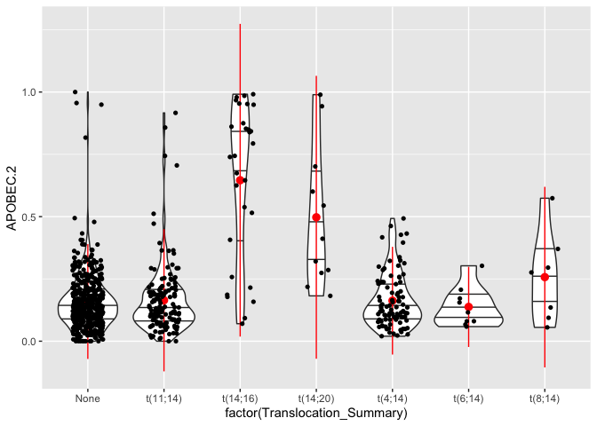

```r
#Apobec mutation signatures are known to cluster by high risk translocations, the following codes for a ***
##PENDING
#Translocation Summary
ggplot(data = MMRFcleanbmionly, aes(x = factor(Translocation_Summary), y = APOBEC.2)) +
    geom_violin(draw_quantiles = c(0.25, 0.5, 0.75)) +
    stat_summary(fun.data=mean_sdl, mult=1,
                 geom="pointrange", color="red") +
    geom_jitter(shape=16, position=position_jitter(0.2))
```

```r
lm5 <- lm(APOBEC.2 ~ Translocation_Summary, data = MMRFcleanbmionly)
modelsummary(list(lm5), coef_omit = "Intercept",
             statistic = c("p = {p.value}"),
             estimate = "{estimate} [{conf.low}, {conf.high}]")
```

|  | Model 1 |
| --- | --- |
| Translocation_Summaryt(11;14) | 0.005 [−0.020, 0.031] |
|  | p = 0.687 |
| Translocation_Summaryt(14;16) | 0.487 [0.436, 0.538] |
|  | p = <0.001 |
| Translocation_Summaryt(14;20) | 0.338 [0.256, 0.420] |
|  | p = <0.001 |
| Translocation_Summaryt(4;14) | 0.003 [−0.027, 0.034] |
|  | p = 0.824 |
| Translocation_Summaryt(6;14) | −0.022 [−0.112, 0.069] |
|  | p = 0.638 |
| Translocation_Summaryt(8;14) | 0.098 [−0.004, 0.200] |
|  | p = 0.059 |
| Num.Obs. | 758 |
| R2 | 0.356 |
| R2 Adj. | 0.351 |
| AIC | −860.2 |
| BIC | −823.2 |
| Log.Lik. | 438.107 |
| RMSE | 0.14 |

### 3.4.2 CHIP

*Methods (provided to and not performed by me):* In order to identify mutations within the uninvolved peripheral blood DNA as evidence of clonal hematopoesis we took the approach of strictly filtering a set of ultra-sensitive called variants that 1) fell within a low variant allele frequency range (<50%) and 2) occurred within a gene that has been linked to hematopoietic and lymphoid cancers in the Catalogue of Somatic Mutations in Cancer (Genovese NEJM 2014).

*Results:* 74 patients (9.8%) of 753 had concomitant clonal hematopoiesis of indeterminate potential (CHIP). Surprisingly, there appeared to be less CHIP among participant with BMI in the obese range, contrary to what has been previously reported. Again, advanced age was shown positively correlated with higher rates of CHIP.

Because of confounding effects of age and BMI (and possibly to a lesser degree by sex), I performed a multivariate logistic regression to assess for associations between CHIP and age, BMI or sex. Increased OR for CHIP was again demonstrated with age as previously demonstrated in this dataset (Boyle Leukemia 2021). There was also a small but significantly changed OR toward CHIP at 0.95 (CI: 0.90-0.99, p = 0.026) in relationship with BMI. The relationship is redemonstrated when analyzing presence of excess body weight (BMI >30) as a logical variable and is depicted in the barplot graph that follows.

Next, we inquired whether this difference may be driven by distribution of the most common CHIP-related mutations: DNMT3A, TET2, TP53, ASXL1 and PPM1D. Data was available regarding presence or lack of DNMT3A, TET2 and TP53 mutations with frequency of distribution not associated with BMI as shown below.

```r
BMIchip <- MMRFcleanbmionly[1:758, c("BMIDx","BMI_cat_4","EBW_binary","CHIP","AgeDx","Sex","Race")]
BMIchip <- BMIchip %>% filter(!is.na(CHIP))

BMIchip$EBW_binary <- as.numeric(BMIchip$EBW_binary)
BMIchip$CHIP <- as.numeric(BMIchip$CHIP)
wilcox.test(CHIP~EBW_binary, BMIchip)
```

```
##
##  Wilcoxon rank sum test with continuity correction
##
## data:  CHIP by EBW_binary
## W = 66777, p-value = 0.001615
## alternative hypothesis: true location shift is not equal to 0
```

```r
KWCHIP <-kruskal.test(CHIP~BMIDx, BMIchip)
bquote(Chi2 == .(format(KWCHIP$statistic, digits = 2)))
```

```
## Chi2 == c(`Kruskal-Wallis chi-squared` = "683")
```

```r
bquote(p == .(format(KWCHIP$p.value, digits = 5)))
```

```
## p == "0.49816"
```

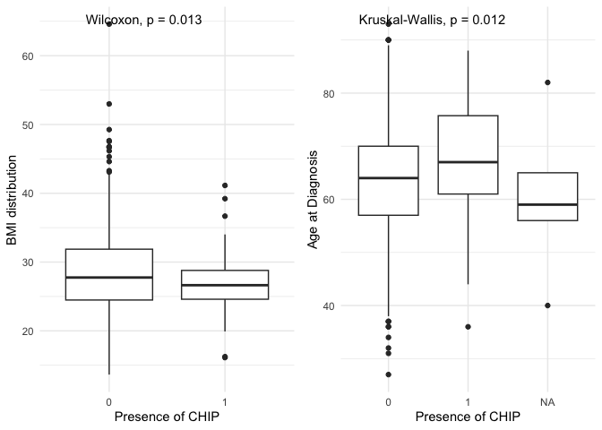

```r
ggplotchipbmi <- ggplot(data = BMIchip, aes(x = factor(CHIP), y = BMIDx), na.rm = TRUE) +
  geom_boxplot() +
  theme_minimal() +
  labs(x = "Presence of CHIP", y = "BMI distribution") +
  stat_compare_means()

#Both as continuous variables
ggplotchipage <- ggplot(data = MMRFcleanbmionly, aes(x = factor(CHIP), y = AgeDx), na.rm = TRUE) +
  geom_boxplot() +
  theme_minimal() +
  labs(x = "Presence of CHIP", y = "Age at Diagnosis")+
  stat_compare_means()

plot_grid(ggplotchipbmi, ggplotchipage, ncol = 2)
```

```r
#Logistic regression for CHIP using age, BMI and sex with BMI as a continuous then with EBW as a binary variable
MMRFcleanbmionly$CHIP <- as.factor(MMRFcleanbmionly$CHIP)
MMRFcleanbmionly$Race <- as.factor(MMRFcleanbmionly$Race)

glm1 <- glm(CHIP ~ AgeDx + Sex + BMIDx,
                  data = MMRFcleanbmionly,
                  family = binomial())
summary(glm1)
```

```
##
## Call:
## glm(formula = CHIP ~ AgeDx + Sex + BMIDx, family = binomial(),
##     data = MMRFcleanbmionly)
##
## Deviance Residuals:
##     Min       1Q   Median       3Q      Max
## -0.8311  -0.4957  -0.4186  -0.3483   2.5102
##
## Coefficients:
##             Estimate Std. Error z value Pr(>|z|)
## (Intercept) -2.85998    1.11486  -2.565  0.01031 *
## AgeDx        0.03265    0.01207   2.705  0.00684 **
## SexMale      0.01766    0.25807   0.068  0.94543
## BMIDx       -0.05474    0.02455  -2.230  0.02577 *
## ---
## Signif. codes:  0 '***' 0.001 '**' 0.01 '*' 0.05 '.' 0.1 ' ' 1
##
## (Dispersion parameter for binomial family taken to be 1)
##
##     Null deviance: 470.42  on 730  degrees of freedom
## Residual deviance: 455.40  on 727  degrees of freedom
##   (27 observations deleted due to missingness)
## AIC: 463.4
##
## Number of Fisher Scoring iterations: 5
```

```r
exp(cbind(OR = coef(glm1), CI = confint(glm1)))
```

```
##                     OR       2.5 %    97.5 %
## (Intercept) 0.05727015 0.006177799 0.4911731
## AgeDx       1.03318813 1.009299192 1.0582804
## SexMale     1.01781962 0.616850542 1.7027282
## BMIDx       0.94673428 0.900881680 0.9918901
```

```r
glm2 <- glm(CHIP ~ AgeDx + Sex + EBW_binary,
                  data = MMRFcleanbmionly,
                  family = binomial())
summary(glm2)
```

```
##
## Call:
## glm(formula = CHIP ~ AgeDx + Sex + EBW_binary, family = binomial(),
##     data = MMRFcleanbmionly)
##
## Deviance Residuals:
##     Min       1Q   Median       3Q      Max
## -0.7281  -0.5117  -0.4207  -0.3126   2.5994
##
## Coefficients:
##               Estimate Std. Error z value Pr(>|z|)
## (Intercept)   -4.08223    0.84990  -4.803 1.56e-06 ***
## AgeDx          0.03211    0.01207   2.660  0.00782 **
## SexMale       -0.03605    0.25654  -0.141  0.88825
## EBW_binary>30 -0.89917    0.32938  -2.730  0.00634 **
## ---
## Signif. codes:  0 '***' 0.001 '**' 0.01 '*' 0.05 '.' 0.1 ' ' 1
##
## (Dispersion parameter for binomial family taken to be 1)
##
##     Null deviance: 470.42  on 730  degrees of freedom
## Residual deviance: 452.09  on 727  degrees of freedom
##   (27 observations deleted due to missingness)
## AIC: 460.09
##
## Number of Fisher Scoring iterations: 5
```

```r
exp(cbind(OR = coef(glm2), CI = confint(glm2)))
```

```
##                       OR       2.5 %     97.5 %
## (Intercept)   0.01686982 0.003043722 0.08554687
## AgeDx         1.03263150 1.008751235 1.05770464
## SexMale       0.96459224 0.586040599 1.60808912
## EBW_binary>30 0.40690668 0.203962307 0.75023068
```

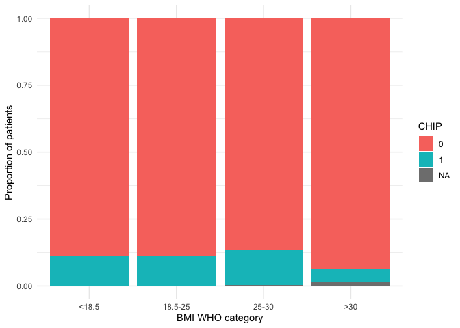

```r
ggplot(MMRFcleanbmionly, aes(fill=CHIP, y=1, x=BMI_cat_4)) +
  geom_bar(position="fill", stat="identity") +
  labs(x = "BMI WHO category", y = "Proportion of patients") +
  theme_minimal()
```

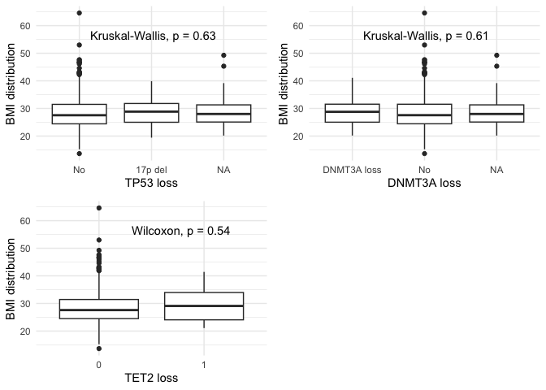

```r
##CHIP mutations:
#TP53
ggplottp53<- ggplot(data = MMRFcleanbmionly, aes(x = factor(TP53_Loss_binary), y = BMIDx), na.rm = TRUE) +
  geom_boxplot() +
  theme_minimal() +
  labs(x = "TP53 loss", y = "BMI distribution") +
  stat_compare_means(label.x = 1.5, label.y = 55)

#DNMT3A
ggplotdnmt3a <- ggplot(data = MMRFcleanbmionly, aes(x = factor(DNMT3A_Loss_binary), y = BMIDx), na.rm = TRUE) +
  geom_boxplot() +
  theme_minimal() +
  labs(x = "DNMT3A loss", y = "BMI distribution") +
  stat_compare_means(label.x = 1.5, label.y = 55)

#TET2
ggplottet2 <- ggplot(data = MMRFcleanbmionly, aes(x = factor(NS_TET2), y = BMIDx), na.rm = TRUE) +
  geom_boxplot() +
  theme_minimal() +
  labs(x = "TET2 loss", y = "BMI distribution") +
  stat_compare_means (label.x = 1.5, label.y = 55)

plot_grid(ggplottp53, ggplotdnmt3a, ggplottet2, ncol = 2)
```

### 3.4.3 TLT and TTL

*Methods (provided to and not performed by me)*: Telomere length was estimated in both tumors and germline using Telomerecat (Farmery Sci Rep 2018).

*Results*: First I checked whether tumor telomere length as associated wiht BMI as a discrete (4 WHO) variable or as a continuous variable. I repeated the same with leukocyte telomere length. Neither measures appeared to correlate with BMI under either model. When considering telomere shortening is a known age-related phenomenon, I looked at the contribution of age and BMI together with a multiple linear regression. Age was associated with shorter tumor telomeres but did not confound BMI related measures in any significant way.

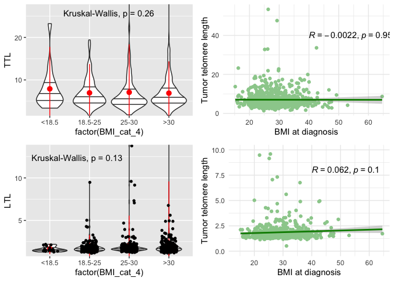

```r
#TTL, BMI discrete
MMRFcleanbmionly$TTL <- as.numeric(MMRFcleanbmionly$TTL)
ylim1 = boxplot.stats(MMRFcleanbmionly$TTL)$stats[c(1, 5)]
TL1 <- ggplot(data = MMRFcleanbmionly, aes(x = factor(BMI_cat_4), y = TTL)) +
    geom_violin(draw_quantiles = c(0.25, 0.5, 0.75)) +
    stat_summary(fun.data=mean_sdl, mult=1,
                 geom="pointrange", color="red") +
  coord_cartesian(ylim = ylim1*2) +
  stat_compare_means(label.x = 1.8, label.y = 25)

#TTL, BMI continuous
TL2 <- ggplot(MMRFcleanbmionly, aes(x = BMIDx, y = TTL)) +
    geom_point(color = "darkseagreen3") +
    geom_smooth(method = "lm", color = "green4") +
    labs(x = "BMI at diagnosis", y = "Tumor telomere length") +
    stat_cor(method = "pearson", label.x = 40, label.y = 40) +
    theme_minimal ()

#LTL, BMI discrete
MMRFcleanbmionly$LTL <- as.numeric(MMRFcleanbmionly$LTL)
ylim2 = boxplot.stats(MMRFcleanbmionly$LTL)$stats[c(1, 5)]
TL3 <- ggplot(data = MMRFcleanbmionly, aes(x = factor(BMI_cat_4), y = LTL)) +
    geom_violin(draw_quantiles = c(0.25, 0.5, 0.75), ylim = range(0:6)) +
    stat_summary(fun.data=mean_sdl, mult=1,
                 geom="pointrange", color="red") +
    geom_jitter(shape=16, position=position_jitter(0.2)) +
    stat_compare_means(label.x = 1, label.y = 12)+
  coord_cartesian(ylim = ylim1*1)


#LTL, BMI continuous
TL4 <- ggplot(MMRFcleanbmionly, aes(x = BMIDx, y = LTL)) +
    geom_point(color = "darkseagreen3") +
    geom_smooth(method = "lm", color = "green4") +
    labs(x = "BMI at diagnosis", y = "Tumor telomere length") +
    stat_cor(method = "pearson", label.x = 40, label.y = 8) +
    theme_minimal() +
    ylim(0,10)

plot_grid(TL1, TL2, TL3, TL4, ncol = 2)
```

```r
#Multiple linear regressions when also considering age and BMI
#TTL
lm1<- lm(TTL~BMIDx + AgeDx, MMRFcleanbmionly)
summary(lm1)
```

```
##
## Call:
## lm(formula = TTL ~ BMIDx + AgeDx, data = MMRFcleanbmionly)
##
## Residuals:
##    Min     1Q Median     3Q    Max
## -6.282 -2.401 -1.152  1.062 46.596
##
## Coefficients:
##             Estimate Std. Error t value Pr(>|t|)
## (Intercept) 10.65526    1.38710   7.682 5.26e-14 ***
## BMIDx       -0.01366    0.02857  -0.478   0.6327
## AgeDx       -0.05098    0.01579  -3.228   0.0013 **
## ---
## Signif. codes:  0 '***' 0.001 '**' 0.01 '*' 0.05 '.' 0.1 ' ' 1
##
## Residual standard error: 4.49 on 705 degrees of freedom
##   (50 observations deleted due to missingness)
## Multiple R-squared:  0.01457,    Adjusted R-squared:  0.01178
## F-statistic: 5.213 on 2 and 705 DF,  p-value: 0.005656
```

```r
#TLT
lm2<- lm(LTL~BMIDx + AgeDx, MMRFcleanbmionly)
summary(lm2)
```

```
##
## Call:
## lm(formula = LTL ~ BMIDx + AgeDx, data = MMRFcleanbmionly)
##
## Residuals:
##    Min     1Q Median     3Q    Max
## -1.425 -0.511 -0.304 -0.027 54.859
##
## Coefficients:
##             Estimate Std. Error t value Pr(>|t|)
## (Intercept) 0.759049   0.747775   1.015    0.310
## BMIDx       0.015059   0.015441   0.975    0.330
## AgeDx       0.012704   0.008545   1.487    0.138
##
## Residual standard error: 2.417 on 704 degrees of freedom
##   (51 observations deleted due to missingness)
## Multiple R-squared:  0.004015,   Adjusted R-squared:  0.001186
## F-statistic: 1.419 on 2 and 704 DF,  p-value: 0.2427
```

### 3.4.4 Differential gene expression and FSGEA between participants with BMI 18.5-25 and BMI >30

*Methods (provided to and not performed by me)*: A subset of 683 samples from the CoMMpass study had RNA sequencing available (Manojlovic Plos genet 2017). Data were aligned to hg38 using STAR (2.5.1b)(11) and quality controlled using QoRTS (v1.2.42) (12) with alignment and quantification of gene read count with Salmon (v0.7.2).(13) Normalization of counts and differential gene expression analysis was performed using DESeq2 (v1.14.1)(Torres PNaS 2019). In this analysis, we compared the gene expression profile of tumors from participant with BMI 18.5-25 (BMI_1) and BMI >30 (BMI_3).

*Results*: A volcano plot distribution of the differential gene expression (LogFC between both groups) is shown below. The red-black divide shows the difference between statistically significant and insignificant genes. Yet, all LogFC were modest, none greater than 1 and with the majority falling below 0.5, already suggestive no significant pathway expression differences between the two groups.

For further investigation, I also ranked the differentially expressed genes according to LogFC (t-statistic from the DES was not available) and performed a functional set enrichment analysis. When using a subset of statistically significant genes, there appeared to be net enrichment toward the KEGG_CYTOKINE_CYTOKINE_RECEPTOR_INTERACTION pathway. However, this finding was not supported when using an overrepresenation analysis, according to the online the enrichment analysis tool [Database for Annotation, Visualization and Integrated Discovery (DAVID)](https://david.ncifcrf.gov/). A modified fisher exact p-value that is implemented in DAVID to test for overrepresentation suggested an overrepresentation that was not statistically significant.

Overall, there do not appear to be any significant gene expression changes between obese and non-obese patients tumors in this dataset.

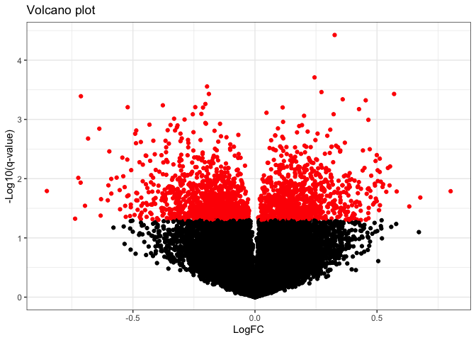

```r
#Changes to DGE data.frame
MMRFdge$sig <- rep("insignificant", nrow(MMRFdge))
MMRFdge$sig[which(MMRFdge$ANOVA<0.05)] <- "significant"
MMRFdge[c('Gene','num')] <- str_split_fixed(MMRFdge$Gene_name, "_", n=2)
MMRFsigdge <- MMRFdge %>%
  filter(sig == "significant")
MMRFsigdge <- MMRFsigdge[1:2069, c("Gene","foldchange","ANOVA", "BMI_1", "BMI_3")]
MMRFsigdge <- rename(MMRFsigdge, p.value = ANOVA)

#Volcano Plot
ggplot(MMRFdge, aes(x = foldchange, y = -log10(ANOVA), color = sig)) +
  geom_point() +
  theme_bw() +
  ggtitle("Volcano plot") +
  xlab("LogFC")+
  ylab("-Log10(q-value)") +
  scale_color_manual(values = c("black", "red")) +
  theme(legend.position = "none")
```

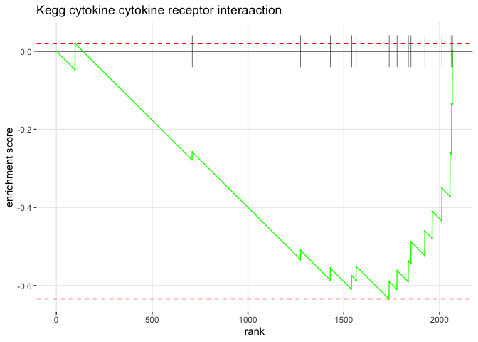

```r
#FSGEA
library(fgsea)
kegg <- gmtPathways("~/Documents/BMIN 5030/Assignment 6/c2.cp.kegg.v7.4.symbols.gmt")
reactome <- gmtPathways("~/Documents/BMIN 5030/Assignment 6/c2.cp.reactome.v7.4.symbols.gmt")
pathways <- c(kegg, reactome)

##Inspecting? No need to remove any gene names
MMRFsigdge <- MMRFsigdge %>%
  group_by(Gene) %>%
  arrange(foldchange) %>%
  filter(row_number() == 1) %>%
  data.frame()

#List ranking genes by LogFC at the t-statistic was not available to me (acceptable albeit not ideal strategy as I am told)
gene_list <- MMRFsigdge$foldchange
names(gene_list) <- MMRFsigdge$Gene
gene_list <- sort(gene_list, decreasing = T)

#FGSEA
fgseaRes <- fgsea(pathways = pathways, stats = gene_list, minSize = 15,
                  maxSize = 500, nperm = 10000, gseaParam = 1)
fgseaRes <- fgseaRes[order(fgseaRes$pval), ]

#Will not collapse pathways - although only 26 pathways came up, only one with NES >2 with sig adjusted p-value, that is, KEGG_CYTOKINE_CYTOKINE_RECEPTOR_INTERACTION
#Here is the enrichment pathway
plotEnrichment(pathway = pathways[["KEGG_CYTOKINE_CYTOKINE_RECEPTOR_INTERACTION"]], stats = gene_list) +
  labs(title="Kegg cytokine cytokine receptor interaaction")
```

```r
#Which is enriched by the following differentially expressed genes
fgseaRes %>%
  filter(pathway == "KEGG_CYTOKINE_CYTOKINE_RECEPTOR_INTERACTION") %>%
  dplyr::select(leadingEdge) %>%
  unlist() %>%
  unname()
```

```
##  [1] "CCR5"    "CCL1"    "CCR1"    "CCR2"    "IL4"     "IL12RB1" "IFNG"
##  [8] "IL21R"   "IL22RA2" "TPO"
```

```r
#DE genes in list form
DE_genes <- as.character(MMRFdge$Gene)[which(MMRFdge$ANOVA < 0.05)]

#Creation of 2x2 table
PT <- as.character(MMRFdge$Gene)
PH <- intersect(PT, pathways[["KEGG_CYTOKINE_CYTOKINE_RECEPTOR_INTERACTION"]])
LT <- DE_genes
LH <- intersect(PH, LT)
PH_LH <- setdiff(PH, LH) #PH-LH
LT_LH <- setdiff(LT, LH) #LT-LH
PT_LT_PH_LH <- setdiff(setdiff(PT, LT), PH_LH)
mat <- matrix(
  c(length(LH), length(PH_LH), length(LT_LH), length(PT_LT_PH_LH)),
  ncol = 2, nrow = 2,
  dimnames = list(c("in pathway", "not in pathway"), c("DE genes", "background genes")), byrow = T)

#EASE score
mat <- matrix(
  c(length(LH) - 1, length(PH_LH) + 1,
    length(LT_LH), length(PT_LT_PH_LH)),
  ncol = 2, nrow = 2,
  dimnames = list(c("in pathway", "not in pathway"),
                  c("DE genes", "background genes")), byrow = T)
mat
```

```
##                DE genes background genes
## in pathway           15              248
## not in pathway     2053            53945
```

```r
#FISHER exact test
fisher.test(mat, alternative = "greater")
```

```
##
##  Fisher's Exact Test for Count Data
##
## data:  mat
## p-value = 0.06317
## alternative hypothesis: true odds ratio is greater than 1
## 95 percent confidence interval:
##  0.9650176       Inf
## sample estimates:
## odds ratio
##   1.589249
```

```r
#FGSEA with all significant and insignificant genes then collapsing pathways, again ranking by LogFC
MMRFdge <- MMRFdge %>%
  group_by(Gene) %>%
  arrange(ANOVA) %>%
  filter(row_number() == 1) %>%
  data.frame()

gene_list1 <- MMRFdge$foldchange
names(gene_list1) <- MMRFdge$Gene
gene_list1 <- sort(gene_list1, decreasing = T)

fgseaRes1 <- fgsea(pathways = pathways, stats = gene_list1, minSize = 15,
                  maxSize = 500, nperm = 10000, gseaParam = 1)
fgseaRes1 <- fgseaRes1[order(fgseaRes1$pval), ]

#When collapsing pathways:
collapsedPathways <- collapsePathways(fgseaRes = fgseaRes1[padj < 0.05],
                                      pathways = pathways, stats = gene_list1)
mainPathways <- fgseaRes1[pathway %in% collapsedPathways$mainPathways] # keep results of independent pathways
head(mainPathways)
```

```
## Empty data.table (0 rows and 8 cols): pathway,pval,padj,ES,NES,nMoreExtreme...
```

# 4 DISCUSSION AND CONCLUSIONS:

No clinically established adverse cytogenetic features of NDMM are associated with BMI at the time of diagnosis. High risk GEP70 and ISS scores appear to weigh less significantly on survival in patients with excess body weight, although this is likely due to relatively small sample sizes that are underpowered for weighing differences in prognostic factors among obese and non-obese patients. Larger cohorts might identify whether additional comorbid conditions are modifying the risk contribution of these clinically validated prognostic factors and might additionally reveal any drug-specific issues relating to excess body weight the the era of targeted MM therapies.

Regarding the exploratory germline and tumor genetic analyses, none suggested an underlying mechanism for myeloma as an obesity-related cancer (ORC). Rather, there is less CHIP in obese patients in this cohort which is contrary to what has been previously reported in the literature. This finding does not seems to be due to differences in TP53, DNMT3A or TET2 mutations, although, in general, these are all rare events in NDMM. As such, the reason for these differences are unclear, but unlikely to be skewing any other analyses in this report.

Overall, these data suggest that NDMM in obese patients is the same, prognostically and genetically, as that in patients with a normal BMI at the time of diagnosis. The excess number of cases cannot be attributed to a disproportionate frequency of driver mutation events, APOBEC mutation signatures, CHIP, telomere length and tumor GEP. While I showed these traits are distributed evenly across BMI at the time of diagnosis, individuals with EBW are also disproportionately affected by monoclonal gammopathy of undeterminate significance (MGUS), the pre-cancerous lesion associated with MM. Whatever the malignant driving pressure or pressures associated obesity may be, they are likely present well before the time of cancer diagnosis and therefore may be too late to capture in a dataset composed of only MM patients such as this one.

BMI is also a limited measure of adiposity, often not reflecting the true incidence of biological changes associated with excess adipose tissue. Studies using increased waist to hip ratio or other radiology-based measures of adipose tissue should be considered and may help answer some of these questions.

Finally, while I included some tumor genetic information, systemic and marrow niche changes also play a role in malignant transformation and they are inherently not captured by this study. Thus, single cell level data of the stromal and immune tumor microenvironment might also highlight any obesity-related differences, albeit with increasing complexity and the ongoing need for appropriately statistically powered analyses.

# 5 REFERENCES

1. Carson, K. R., M. L. Bates, and M. H. Tomasson. 2014. “The Skinny on Obesity and Plasma Cell Myeloma: A Review of the Literature.” Bone Marrow Transplantation 49(8): 1009–15.
2. Landgren, Ola et al. 2009. “Monoclonal Gammopathy of Undetermined Significance (MGUS) Consistently Precedes Multiple Myeloma: A Prospective Study.” Blood.
3. Wallin, Alice, and Susanna C. Larsson. 2011. “Body Mass Index and Risk of Multiple Myeloma: A Meta-Analysis of Prospective Studies.” European Journal of Cancer.
4. Islami, Farhad, Ann Goding Sauer, Susan M. Gapstur, and Ahmedin Jemal. 2019. “Proportion of Cancer Cases Attributable to Excess Body Weight by US State, 2011-2015.” JAMA Oncology 5(3): 384–92
5. Abar, L. et al. 2019. “Body Size and Obesity during Adulthood, and Risk of Lympho-Haematopoietic Cancers: An Update of the WCRF-AICR Systematic Review of Published Prospective Studies.” Annals of Oncology 30(4): 528–41.
6. Teras, Lauren R. et al. 2014. “Body Size and Multiple Myeloma Mortality: A Pooled Analysis of 20 Prospective Studies.” British Journal of Haematology.
7. Beason, T. S. et al. 2013. “Influence of Body Mass Index on Survival in Veterans With Multiple Myeloma.” The Oncologist.
8. Vogl, Dan T. et al. 2011. “Effect of Obesity on Outcomes after Autologous Hematopoietic Stem Cell Transplantation for Multiple Myeloma.” Biology of Blood and Marrow Transplantation 17(12): 1765–74.
9. Fonseca, R. et al. 2017. “Trends in Overall Survival and Costs of Multiple Myeloma, 2000-2014.” Leukemia.
10. Santhosh Kumar Pasupuleti, Baskar Ramdas, Sarah S. Burns, Ramesh Kumar, Taruni Reddy Pandhiri, George Sandusky, Zhi Yu, Michael Honigberg, Alexander G. Bick, Gabriel K. Griffin, Abhishek Niroula, Benjamin L. Ebert, Pradeep Natarajan, Reuben Kapur; Obesity-Induced Inflammation Co-Operates with Clonal Hematopoiesis of Indeterminate Potential (CHIP) Mutants to Promote Leukemia Development and Cardiovascular Disease. Blood 2021; 138
11. Mouhieddine, T.H., Sperling, A.S., Redd, R. et al. Clonal hematopoiesis is associated with adverse outcomes in multiple myeloma patients undergoing transplant. Nat Commun 11, 2996 (2020). https://doi.org/10.1038/s41467-020-16805-5
12. Gielen, Marij et al. “Body mass index is negatively associated with telomere length: a collaborative cross-sectional meta-analysis of 87 observational studies.” The American journal of clinical nutrition vol. 108,3 (2018): 453-475.
13. Wu, Kai-Da et al. “Telomerase and telomere length in multiple myeloma: correlations with disease heterogeneity, cytogenetic status, and overall survival.” Blood vol. 101,12 (2003): 4982-9. doi:10.1182/blood-2002-11-3451
14. Steinbrecher, Daniela et al. “Telomere length in poor-risk chronic lymphocytic leukemia: associations with disease characteristics and outcome.” Leukemia & lymphoma vol. 59,7 (2018): 1614-1623.
15. Boyle, Eileen M et al. “Improving prognostic assignment in older adults with multiple myeloma using acquired genetic features, clonal hemopoiesis and telomere length.” Leukemia vol. 36,1 (2022): 221-224.
16. Genovese G, Kähler AK, Handsaker RE, et al. Clonal Hematopoiesis and Blood-Cancer Risk Inferred from Blood DNA Sequence. N. Engl. J. Med. 2014;371(26):2477–2487)
17. Farmery JHR, Smith ML, Lynch AG. Telomerecat: A ploidy-agnostic method for estimating telomere length from whole genome sequencing data. Sci. Rep. 2018;8(1):1300)
18. Manojlovic Z, Christofferson A, Liang WS, et al. Comprehensive molecular profiling of 718 Multiple Myelomas reveals significant differences in mutation frequencies between African and European descent cases. PLoS Genet. 2017;13
19. Torres AG, Reina O, Attolini CS-O, Pouplana LR de. Differential expression of human tRNA genes drives the abundance of tRNA-derived fragments. Proc. Natl. Acad. Sci. 2019;116(17):8451–8456.